# Sesion 7 del Club de Lectura ‘Efficient R Programming’

Denisse Fierro Arcos

2022-06-20

Este Club de Lectura es una colaboracion entre la Universidad Nacional de Colombia y los capitulos R-Ladies de Barranquilla, Medellin (COL) y Galapagos (ECU).

En esta guia ligada a la septima sesion estaremos cubriendo como conectarnos con bases de datos `SQL` desde R. Tambien hablaremos sobre como procesar datos usando el paquete `data.table`.

## Trabajando con bases de datos en R

Usar bases de datos en nuestros analisis ayuda a evitar sobrecargar la memoria RAM. Esto es especialmente relevante cuando trabajamos con bases de datos que contienen miles o millones de observaciones.

Como siempre, empecemos llamando a librerias relevantes.

```r
library(RSQLite)
library(DBI)
```

Ahora necesitamos crear una conexion que nos permita trabajar con bases de datos.

```r
con_bases <- datasetsDb()
```

A pesar que parece que no ocurrio nada, podemos verificar que una conexion ha sido creada llamando a la variable que contiene esta conexion `con_bases`.

```
## <SQLiteConnection>
##   Path: C:\Users\ldfierro\Documents\R\win-library\4.0\RSQLite\db\datasets.sqlite
##   Extensions: TRUE
```

Ahora que tenemos una conexion lista, podemos crear una lista de las bases de datos que tenemos disponibles.

```r
dbListTables(con_bases)
```

```
##  [1] "BOD"              "CO2"              "ChickWeight"      "DNase"
##  [5] "Formaldehyde"     "Indometh"         "InsectSprays"     "LifeCycleSavings"
##  [9] "Loblolly"         "Orange"           "OrchardSprays"    "PlantGrowth"
## [13] "Puromycin"        "Theoph"           "ToothGrowth"      "USArrests"
## [17] "USJudgeRatings"   "airquality"       "anscombe"         "attenu"
## [21] "attitude"         "cars"             "chickwts"         "esoph"
## [25] "faithful"         "freeny"           "infert"           "iris"
## [29] "longley"          "morley"           "mtcars"           "npk"
## [33] "pressure"         "quakes"           "randu"            "rock"
## [37] "sleep"            "stackloss"        "swiss"            "trees"
## [41] "warpbreaks"       "women"
```

**NOTA:** Si tienes acceso a un sistema de manejo de bases de datos (DMBS), entonces puedes conectarte al mismo usando la funcion `dbConnect`. Deberas asegurarte de tener a la mano tu usuario, clave, nombre y puerto del host, asi como el nombre de la base de datos a la que quieres acceder.

Debido a que no tenemos acceso a un DBMS que sea publico no podemos usar esta opcion. Pero abajo incluimos el codigo que deberias usart

```r
con <- dbConnect(SQLite(), user = "nombre_usuario",
                 password = "clave",
                 host = "nombre_host",
                 port = "puerto_host",
                 dbname = "nombre_base_datos")
```

Volviendo a las bases de datos que tenemos disponibles a traves del paquete `RSQLite`, vamos a escoger la base `quakes` para este ejemplo.

Para cargar la base de datos a nuestra sesion de R utilizamos la funcion `dbReadTable`.

```r
base_terremoto <- dbReadTable(con_bases, "quakes")
head(base_terremoto)
```

```
##      lat   long depth mag stations
## 1 -20.42 181.62   562 4.8       41
## 2 -20.62 181.03   650 4.2       15
## 3 -26.00 184.10    42 5.4       43
## 4 -17.97 181.66   626 4.1       19
## 5 -20.42 181.96   649 4.0       11
## 6 -19.68 184.31   195 4.0       12
```

Pero tambien tenemos la opcion de escoger una muestra de estos datos basados en una condicion. Por ejemplo, terremotos con magnitud mayor a 5.

```r
terremotos <- dbGetQuery(con_bases, "SELECT * FROM quakes WHERE mag >= 5")
head(terremotos)
```

```
##      lat   long depth mag stations
## 1 -26.00 184.10    42 5.4       43
## 2 -20.70 169.92   139 6.1       94
## 3 -13.64 165.96    50 6.0       83
## 4 -19.66 180.28   431 5.4       57
## 5 -16.46 180.79   498 5.2       79
## 6 -18.97 185.25   129 5.1       73
```

Para no cargar toda la base a la memoria, vamos a mostrar solo las primeras cinco lineas.

```r
terremotos_2 <- dbSendQuery(con_bases, "SELECT * FROM quakes WHERE mag >= 5")
dbFetch(terremotos_2, n = 5)
```

```
##      lat   long depth mag stations
## 1 -26.00 184.10    42 5.4       43
## 2 -20.70 169.92   139 6.1       94
## 3 -13.64 165.96    50 6.0       83
## 4 -19.66 180.28   431 5.4       57
## 5 -16.46 180.79   498 5.2       79
```

Podemos tambien usar el paquete `tidyverse` para poder manipular las bases de datos de manera mas eficiente. Primero vamos a cargar el paquete.

```r
library("tidyverse")
```

Podemos entonces cargar la base de datos con tidyverse. Podemos cargarla completamente.

```r
con_bases %>%
  tbl("quakes") %>%
  head()
```

```
## # Source:   lazy query [?? x 5]
## # Database: sqlite 3.38.5
## #   [C:\Users\ldfierro\Documents\R\win-library\4.0\RSQLite\db\datasets.sqlite]
##     lat  long depth   mag stations
##   <dbl> <dbl> <int> <dbl>    <int>
## 1 -20.4  182.   562   4.8       41
## 2 -20.6  181.   650   4.2       15
## 3 -26    184.    42   5.4       43
## 4 -18.0  182.   626   4.1       19
## 5 -20.4  182.   649   4         11
## 6 -19.7  184.   195   4         12
```

Pero tambien podemos seleccionar una parte de la base de datos basados en una condicion. Aqui tenemos dos opciones, utilizar la funcion `sql` para hacer la seleccion de datos.

```r
con_bases %>%
  tbl(sql("SELECT * FROM quakes WHERE mag >= 5")) %>%
  head()
```

```
## # Source:   lazy query [?? x 5]
## # Database: sqlite 3.38.5
## #   [C:\Users\ldfierro\Documents\R\win-library\4.0\RSQLite\db\datasets.sqlite]
##     lat  long depth   mag stations
##   <dbl> <dbl> <int> <dbl>    <int>
## 1 -26    184.    42   5.4       43
## 2 -20.7  170.   139   6.1       94
## 3 -13.6  166.    50   6         83
## 4 -19.7  180.   431   5.4       57
## 5 -16.5  181.   498   5.2       79
## 6 -19.0  185.   129   5.1       73
```

Tambien podemos simplemente cargar la base de datos como un data frame o tabla y utilizar funciones de tidyverse para seleccionar datos basados en las mismas condiciones.

```r
tbl(con_bases, "quakes") %>%
  filter(mag >= 5) %>%
  head()
```

```
## # Source:   lazy query [?? x 5]
## # Database: sqlite 3.38.5
## #   [C:\Users\ldfierro\Documents\R\win-library\4.0\RSQLite\db\datasets.sqlite]
##     lat  long depth   mag stations
##   <dbl> <dbl> <int> <dbl>    <int>
## 1 -26    184.    42   5.4       43
## 2 -20.7  170.   139   6.1       94
## 3 -13.6  166.    50   6         83
## 4 -19.7  180.   431   5.4       57
## 5 -16.5  181.   498   5.2       79
## 6 -19.0  185.   129   5.1       73
```

Con esta ultima opcion es facil crear graficos con las bases de datos en un solo chunk de codigo.

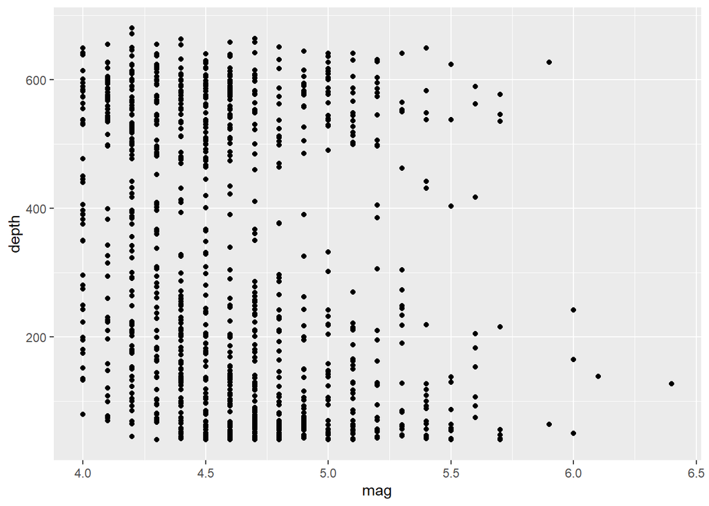

```r
tbl(con_bases, "quakes") %>%
  ggplot(aes(x = mag, y = depth))+
  geom_point()
```

Una vez que terminemos de utilizar las bases de datos podemos desconectarnos.

```r
dbDisconnect(conn = con_bases)
```

Finalmente, tambien es posible crear una base de datos SQL desde R en unas pocas lineas de codigo. Primero debemos crear una base de datos SQL.

```r
#Vamos a utilizar SQLite para crear nuestra base de datos y la vamos a guardar en nuestra memoria.
mi_base <- dbConnect(SQLite(), "")

#Verificamos que ha sido creada exitosamente
mi_base
```

```
## <SQLiteConnection>
##   Path:
##   Extensions: TRUE
```

Ahora vamos a guardar tres bases de datos que estan disponibles en paquetes de R: `mtcars`, `iris` y `starwars`. Empecemos con `mtcars`, la vamos a guardar tal como esta en R.

```r
copy_to(mi_base, mtcars)
dbListTables(mi_base)
```

```
## [1] "mtcars"       "sqlite_stat1" "sqlite_stat4"
```

```r
copy_to(mi_base, iris, indexes = list("Petal.Width", "species"))
dbListTables(mi_base)
```

```
## [1] "iris"         "mtcars"       "sqlite_stat1" "sqlite_stat4"
```

Finalmente guardaremos `starwars`. Debido a que esta tibble incluye listas en ciertas columnas y estas no son compatibles con bases de datos SQL, vamos a seleccionar solo las columnas que no contengan listas.

```r
dbWriteTable(mi_base, "starwars", starwars %>% select(!where(is_list)))
dbListTables(mi_base)
```

```
## [1] "iris"         "mtcars"       "sqlite_stat1" "sqlite_stat4" "starwars"
```

Podemos acceder a estos datos tal como lo hicimos anteriormente con el paquete `tidyverse`.

```r
mi_base %>%
  tbl("starwars")
```

```
## # Source:   table<starwars> [?? x 11]
## # Database: sqlite 3.38.5 []
##    name    height  mass hair_color  skin_color eye_color birth_year sex   gender
##    <chr>    <int> <dbl> <chr>       <chr>      <chr>          <dbl> <chr> <chr>
##  1 Luke S…    172    77 blond       fair       blue            19   male  mascu…
##  2 C-3PO      167    75 <NA>        gold       yellow         112   none  mascu…
##  3 R2-D2       96    32 <NA>        white, bl… red             33   none  mascu…
##  4 Darth …    202   136 none        white      yellow          41.9 male  mascu…
##  5 Leia O…    150    49 brown       light      brown           19   fema… femin…
##  6 Owen L…    178   120 brown, grey light      blue            52   male  mascu…
##  7 Beru W…    165    75 brown       light      blue            47   fema… femin…
##  8 R5-D4       97    32 <NA>        white, red red             NA   none  mascu…
##  9 Biggs …    183    84 black       light      brown           24   male  mascu…
## 10 Obi-Wa…    182    77 auburn, wh… fair       blue-gray       57   male  mascu…
## # … with more rows, and 2 more variables: homeworld <chr>, species <chr>
```

O tenemos la opcion de cargarlo como una base de SQL.

```r
dbReadTable(mi_base, "starwars")
```

```
##                     name height   mass    hair_color          skin_color
## 1         Luke Skywalker    172   77.0         blond                fair
## 2                  C-3PO    167   75.0          <NA>                gold
## 3                  R2-D2     96   32.0          <NA>         white, blue
## 4            Darth Vader    202  136.0          none               white
## 5            Leia Organa    150   49.0         brown               light
## 6              Owen Lars    178  120.0   brown, grey               light
## 7     Beru Whitesun lars    165   75.0         brown               light
## 8                  R5-D4     97   32.0          <NA>          white, red
## 9      Biggs Darklighter    183   84.0         black               light
## 10        Obi-Wan Kenobi    182   77.0 auburn, white                fair
## 11      Anakin Skywalker    188   84.0         blond                fair
## 12        Wilhuff Tarkin    180     NA  auburn, grey                fair
## 13             Chewbacca    228  112.0         brown             unknown
## 14              Han Solo    180   80.0         brown                fair
```

[output cut: 249 more lines]

No olvidemos de cerrar nuestra sesion.

```r
dbDisconnect(mi_base)
```

## Procesando datos con `data.table`

El paquete `data.table` ofrece otra opcion para manipular datos en R, pero tiene funciones similares a las ofrecidas por el paquete `dplyr` que esta incluido en el `tidyverse`. Ambos paquetes son eficientes para el procesamiento de datos y cual es utilizado dependera de la preferencia de la persona que programa. En esta seccion mostramos un ejemplo de como utilizar el paquete `data.table` para seleccionar datos basados en una condicion.

Empecemos cargando las librerias que vamos a necesitar para esta seccion.

```r
library(data.table)
library(datos)
```

Ahora vamos a cargar los datos `paises` desde el paquete `datos` como un `data.table`.

```r
datos_paises <- data.table(paises)
datos_paises
```

```
##             pais continente anio esperanza_de_vida poblacion pib_per_capita
##    1: Afganistán       Asia 1952            28.801   8425333       779.4453
##    2: Afganistán       Asia 1957            30.332   9240934       820.8530
##    3: Afganistán       Asia 1962            31.997  10267083       853.1007
##    4: Afganistán       Asia 1967            34.020  11537966       836.1971
##    5: Afganistán       Asia 1972            36.088  13079460       739.9811
##   ---
## 1700:   Zimbabue     África 1987            62.351   9216418       706.1573
## 1701:   Zimbabue     África 1992            60.377  10704340       693.4208
## 1702:   Zimbabue     África 1997            46.809  11404948       792.4500
## 1703:   Zimbabue     África 2002            39.989  11926563       672.0386
## 1704:   Zimbabue     África 2007            43.487  12311143       469.7093
```

Podemos hacer una seleccion de datos basados en una condicion, similar a la funcion `filter` de la siguiente manera.

```r
datos_paises[pais == "Ecuador" | pais == "Colombia"]
```

```
##         pais continente anio esperanza_de_vida poblacion pib_per_capita
##  1: Colombia   Américas 1952            50.643  12350771       2144.115
##  2: Colombia   Américas 1957            55.118  14485993       2323.806
##  3: Colombia   Américas 1962            57.863  17009885       2492.351
##  4: Colombia   Américas 1967            59.963  19764027       2678.730
##  5: Colombia   Américas 1972            61.623  22542890       3264.660
##  6: Colombia   Américas 1977            63.837  25094412       3815.808
##  7: Colombia   Américas 1982            66.653  27764644       4397.576
##  8: Colombia   Américas 1987            67.768  30964245       4903.219
##  9: Colombia   Américas 1992            68.421  34202721       5444.649
## 10: Colombia   Américas 1997            70.313  37657830       6117.362
## 11: Colombia   Américas 2002            71.682  41008227       5755.260
## 12: Colombia   Américas 2007            72.889  44227550       7006.580
## 13:  Ecuador   Américas 1952            48.357   3548753       3522.111
## 14:  Ecuador   Américas 1957            51.356   4058385       3780.547
## 15:  Ecuador   Américas 1962            54.640   4681707       4086.114
## 16:  Ecuador   Américas 1967            56.678   5432424       4579.074
## 17:  Ecuador   Américas 1972            58.796   6298651       5280.995
## 18:  Ecuador   Américas 1977            61.310   7278866       6679.623
## 19:  Ecuador   Américas 1982            64.342   8365850       7213.791
## 20:  Ecuador   Américas 1987            67.231   9545158       6481.777
## 21:  Ecuador   Américas 1992            69.613  10748394       7103.703
## 22:  Ecuador   Américas 1997            72.312  11911819       7429.456
## 23:  Ecuador   Américas 2002            74.173  12921234       5773.045
## 24:  Ecuador   Américas 2007            74.994  13755680       6873.262
##         pais continente anio esperanza_de_vida poblacion pib_per_capita
```

Podemos ordernar nuestros datos utilizando columnas para hacer la busqueda de datos de manera mas eficiente.

```r
setkey(datos_paises, pais)
a <- datos_paises[.("Ecuador")]
a
```

```
##        pais continente anio esperanza_de_vida poblacion pib_per_capita
##  1: Ecuador   Américas 1952            48.357   3548753       3522.111
##  2: Ecuador   Américas 1957            51.356   4058385       3780.547
##  3: Ecuador   Américas 1962            54.640   4681707       4086.114
##  4: Ecuador   Américas 1967            56.678   5432424       4579.074
##  5: Ecuador   Américas 1972            58.796   6298651       5280.995
##  6: Ecuador   Américas 1977            61.310   7278866       6679.623
##  7: Ecuador   Américas 1982            64.342   8365850       7213.791
##  8: Ecuador   Américas 1987            67.231   9545158       6481.777
##  9: Ecuador   Américas 1992            69.613  10748394       7103.703
## 10: Ecuador   Américas 1997            72.312  11911819       7429.456
## 11: Ecuador   Américas 2002            74.173  12921234       5773.045
## 12: Ecuador   Américas 2007            74.994  13755680       6873.262
```

Podemos agregar mas filas con resultados de otros paises.

```r
a %>%
  bind_rows(datos_paises[.("Colombia")])
```

```
##         pais continente anio esperanza_de_vida poblacion pib_per_capita
##  1:  Ecuador   Américas 1952            48.357   3548753       3522.111
##  2:  Ecuador   Américas 1957            51.356   4058385       3780.547
##  3:  Ecuador   Américas 1962            54.640   4681707       4086.114
##  4:  Ecuador   Américas 1967            56.678   5432424       4579.074
##  5:  Ecuador   Américas 1972            58.796   6298651       5280.995
##  6:  Ecuador   Américas 1977            61.310   7278866       6679.623
##  7:  Ecuador   Américas 1982            64.342   8365850       7213.791
##  8:  Ecuador   Américas 1987            67.231   9545158       6481.777
##  9:  Ecuador   Américas 1992            69.613  10748394       7103.703
## 10:  Ecuador   Américas 1997            72.312  11911819       7429.456
## 11:  Ecuador   Américas 2002            74.173  12921234       5773.045
## 12:  Ecuador   Américas 2007            74.994  13755680       6873.262
## 13: Colombia   Américas 1952            50.643  12350771       2144.115
## 14: Colombia   Américas 1957            55.118  14485993       2323.806
## 15: Colombia   Américas 1962            57.863  17009885       2492.351
## 16: Colombia   Américas 1967            59.963  19764027       2678.730
## 17: Colombia   Américas 1972            61.623  22542890       3264.660
## 18: Colombia   Américas 1977            63.837  25094412       3815.808
## 19: Colombia   Américas 1982            66.653  27764644       4397.576
## 20: Colombia   Américas 1987            67.768  30964245       4903.219
## 21: Colombia   Américas 1992            68.421  34202721       5444.649
## 22: Colombia   Américas 1997            70.313  37657830       6117.362
## 23: Colombia   Américas 2002            71.682  41008227       5755.260
## 24: Colombia   Américas 2007            72.889  44227550       7006.580
##         pais continente anio esperanza_de_vida poblacion pib_per_capita
```

Tal como dijimos al inicio, el mejor paquete para la manipulacion de datos es el que resulte mas comodo para cada persona. No existe una sola respuesta correcta, ya que cada persona tendra preferencias o limitaciones especificas que influencien la decision final de los paquetes que sera utilizados en el proyecto.